# Introduction to the GRIN2 Package

## 12) Pass the Lesion Matrix of Selected Parhways to the OncoPrint Function

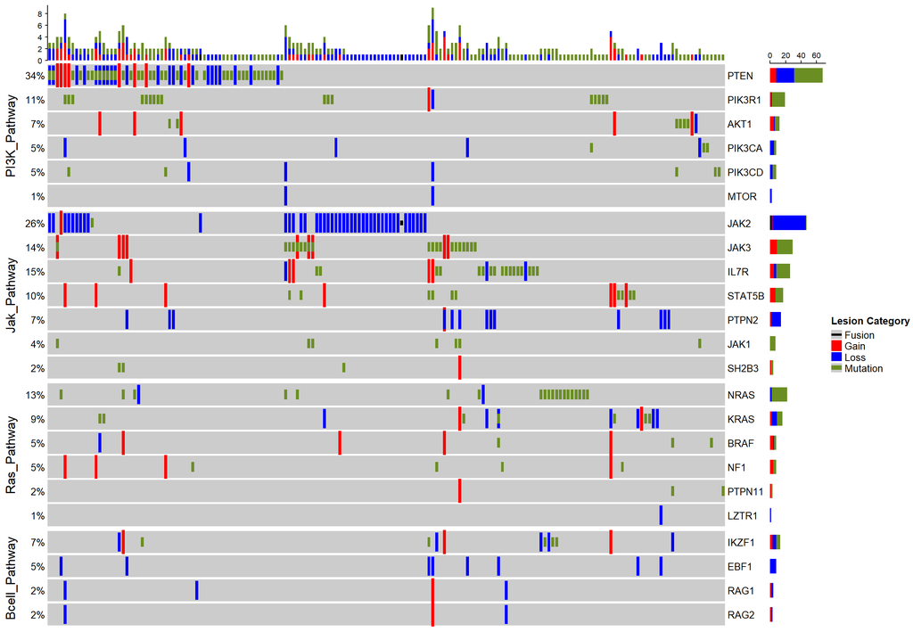

Figure 4. OncoPrint for genes annotated to a selected group of pathways

```r
# Use onco.print.props function to specify a hgt for each lesion category to show all lesions that might affect a certain patient:
onco.props.path<-onco.print.props(lesion.data,
                                  hgt = c("gain"=5, "loss"=4, "mutation"=2, "fusion"=1))
column_title = "" # optional

# use oncoprint function from complexheatmap library to plot the oncoprint
oncoPrint(oncoprint.mtx.path,
          alter_fun = onco.props.path$alter_func,
          col = onco.props.path$col,
          column_title = column_title,
          heatmap_legend_param = onco.props.path$heatmap_legend_param,
          row_split=sel.pathways)
```

## 13) Gene-lesion Plots with GRIN Statistics and Transcripts Track

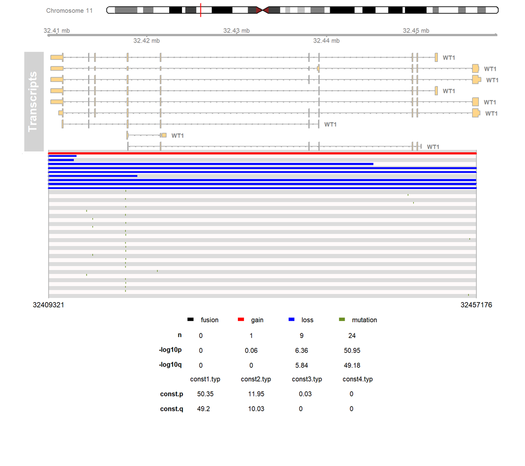

Figure 5. lesion plot showing all different types of lesions affecting WT1 gene with transcripts track directly retreived from Ensembl database

```r
# First we need to call "hg19_cytoband" and "hg38_cytoband" before calling the plot function:
data(hg19_cytoband)
data(hg38_cytoband)

# lsn.transcripts.plot function can be used to generate a plot that shows all different types of lesions that affect a gene of interest with a transcripts track directly retrieved from Ensembl genome browser:
lsn.transcripts.plot(grin.results,
                     genome="hg19",
                     gene="WT1",
                     hg19.cytoband=hg19_cytoband)
```

```r
# for hg38 genome assembly:
# ah <- AnnotationHub()
# retrieve gene transcripts for human GRCh38 genome assembly from Ensembl (version 110):
# gtf.V110 <- ah[["AH113665"]]

#lsn.transcripts.plot(grin.results,
#                     genome="hg38",
#                     gene="WT1",
#                     hg38.transcripts=gtf.V110,
#                     hg38.cytoband=hg38_cytoband)
```

## 14) Locus-lesion Plots with Transcripts Track

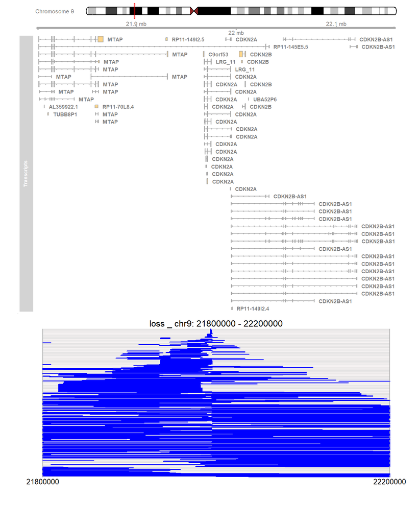

Figure 6. Regional lesion plot showing a specific type of lesion that affect a region of interest

```r
# lsn.transcripts.plot function can be also used to generate a plot for lesions of a specific lesion group that span a certain locus of interest with transcripts track added:
lsn.transcripts.plot(grin.results,
                     genome="hg19",
                     hg19.cytoband=hg19_cytoband,
                     chrom=9,
                     plot.start=21800000,
                     plot.end=22200000,
                     lesion.grp = "loss",
                     spec.lsn.clr = "blue")
```

```r
# for hg38 genome assembly:
# ah <- AnnotationHub()
# retrieve gene transcripts for human GRCh38 genome assembly from Ensembl (version 110):
# gtf.V110 <- ah[["AH113665"]]

#lsn.transcripts.plot(grin.results,
#                     genome="hg38",
#                     hg38.transcripts="gtf.v110",
#                     hg38.cytoband=hg38_cytoband,
#                     chrom=9,
#                     plot.start=21800000,
#                     plot.end=22200000,
#                     lesion.grp = "loss",
#                     spec.lsn.clr = "blue")
```

## 15) Locus-lesion Plots WITHOUT Transcripts Track

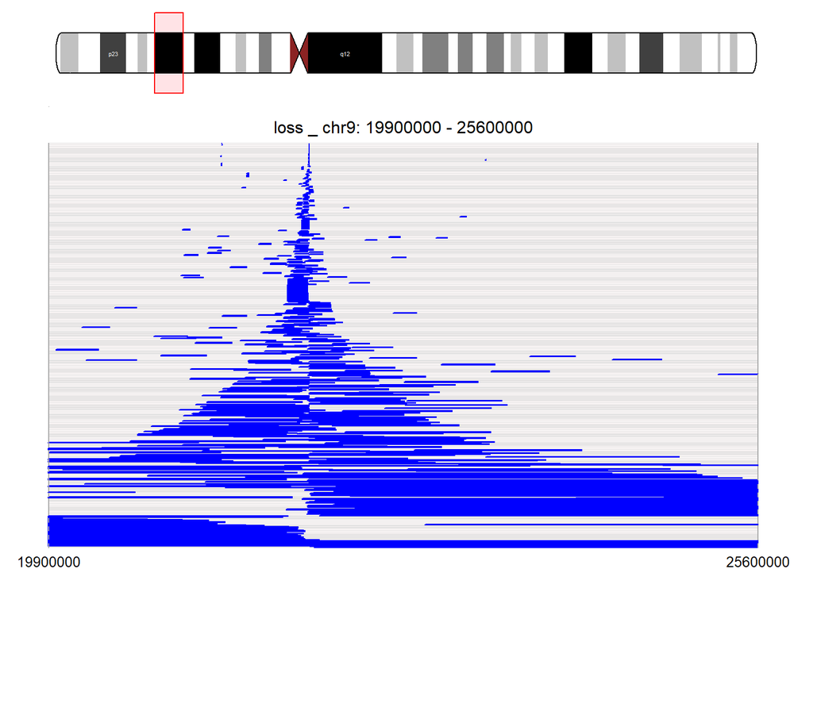

Figure 7. Regional lesion plot showing a specific type of lesion that affect a region of interest

```r
# chrom.lsn.plot function can be used to generate a plot for all lesions of a specific lesion type that affect a locus or region of interest without adding transcripts track. This will allow plotting a larger locus of the chromosome such as a chromosome band.

chrom.lsn.plot(grin.results,
               genome="hg19",
               hg19.cytoband=hg19_cytoband,
               chrom=9,
               plot.start=19900000,
               plot.end=25600000,
               lesion.grp = "loss",
               spec.lsn.clr = "blue")
```

```r
# for hg38 genome assembly:
# ah <- AnnotationHub()
# retrieve gene transcripts for human GRCh38 genome assembly from Ensembl (version 110):
# gtf.V110 <- ah[["AH113665"]]

#chrom.lsn.plot(grin.results,
#               genome="hg38",
#               hg38.transcripts="gtf.v110",
#               hg38.cytoband=hg38_cytoband,
#               chrom=9,
#               plot.start=19900000,
#               plot.end=25600000,
#               lesion.grp = "loss",
#               spec.lsn.clr = "blue")
```

## 16) Chromosome Lesion Plots

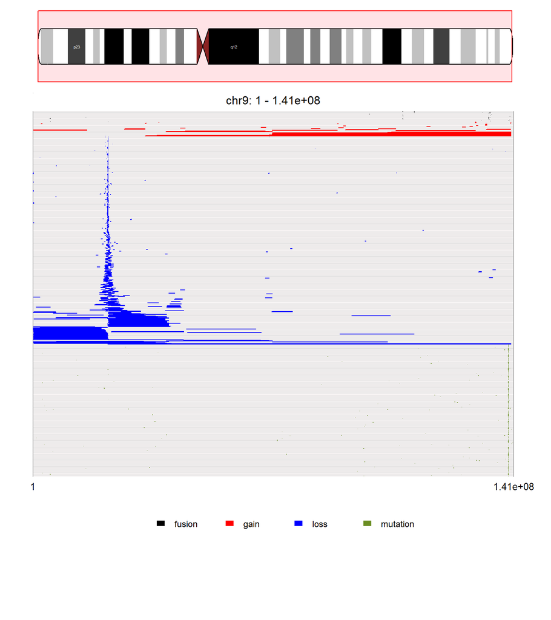

Figure 8. Lesion plot showing different types of lesions that affect a chromosome of interest

```r
# chrom.lsn.plot function can be also used to generate a plot for all types of lesions that affect a chromosome of interest with plot.start=1 and plot.end is the chr size:
chrom.lsn.plot(grin.results,
               genome="hg19",
               hg19.cytoband=hg19_cytoband,
               chrom=9,
               plot.start=1,
               plot.end=141000000)
```

```r
# for hg38 genome assembly:
#ah <- AnnotationHub()
#gtf.V110 <- ah[["AH113665"]]

#chrom.lsn.plot(grin.results,
#               genome="hg38",
#               hg38.transcripts="gtf.v110",
#               hg38.cytoband=hg38_cytoband,
#               chrom=9,
#               plot.start=1,
#               plot.end=141000000)
```

## 17) Regulatory Features Lesion Plots

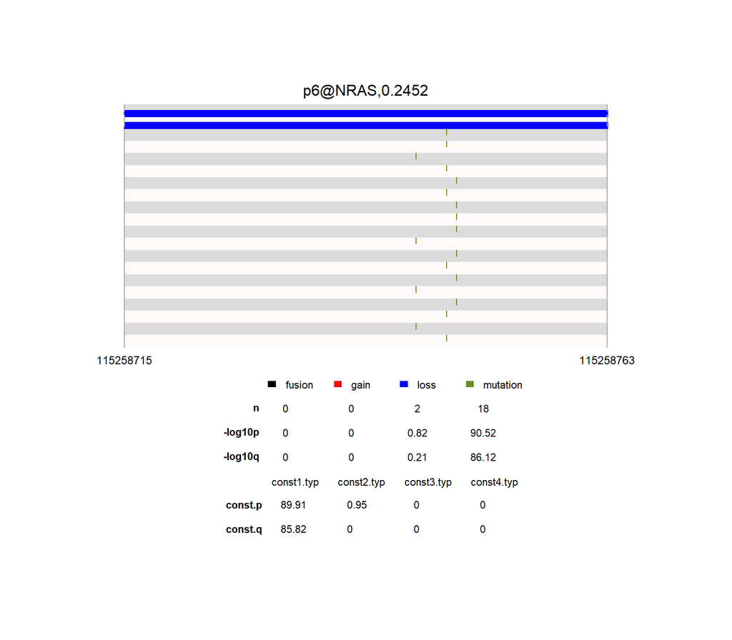

Figure 9. A plot that shows all different types of lesions that affect a regulatory feature of interests in addition the feature GRIN statistics

```r
# grin.stats.lsn.plot function can be used to generate plots that show all different types of lesions that affect a regulatory feature of interest in addition to the GRIN statistics. Plot does not include transcripts track that's typically not available for those features.
# grin.stats.lsn.plot(grin.results.reg,
#                     feature="ENSR00000105619")

# Same plot can be also prepared for regulatory features from the FANTOM5 project (for example: the NRAS promoter site affected by 18 mutations)
grin.stats.lsn.plot(grin.results.fantom,
                    feature="p6@NRAS,0.2452")
```

## 18) Gene-Lesion Matrix for later computations

```r
# Prepare gene and lesion data for later computations
# This lesion matrix has all lesion types that affect a single gene in one row. It can be used to run association analysis with expression data (part of alex.prep.lsn.expr function)

# First step is to prepare gene and lesion data for later computations
gene.lsn=prep.gene.lsn.data(lesion.data,
                            hg19.gene.annotation)
# Then determine lesions that overlap each gene (locus)
gene.lsn.overlap= find.gene.lsn.overlaps(gene.lsn)
# Finally, build the lesion matrix using prep.lsn.type.matrix function:
gene.lsn.type.mtx=prep.lsn.type.matrix(gene.lsn.overlap,
                                       min.ngrp=5)
# prep.lsn.type.matrix function return each gene in a row, if the gene is affected by multiple types of lesions (for example gain AND mutations), entry will be denoted as "multiple" for this specific patient.
# min.ngrp can be used to specify the minimum number of patients with a lesion to be included in the final lesion matrix.

head(gene.lsn.type.mtx[,1:5])
```

```
#>                 PARASZ PARAYM PARCVM PAREGZ PARFDL
#> ENSG00000005700 "loss" "none" "loss" "none" "none"
#> ENSG00000010810 "loss" "none" "loss" "none" "none"
#> ENSG00000014123 "loss" "none" "loss" "none" "none"
#> ENSG00000056972 "loss" "none" "loss" "none" "none"
#> ENSG00000057663 "loss" "none" "loss" "none" "none"
#> ENSG00000065615 "loss" "none" "loss" "none" "none"
```

## Associate Lesions with EXpression (ALEX)

## 19) Prepare Expression and Lesion Data for ALEX-KW Test and ALEX-plots

```r
# alex.prep.lsn.expr function prepare expression, lesion data and return the set of genes with both types of data available ordered by gene IDs in rows and patient IDs in columns:

alex.data=alex.prep.lsn.expr(expr.data,
                             lesion.data,
                             hg19.gene.annotation,
                             min.expr=1,
                             min.pts.lsn=5)

# ALEX ordered lesion data:
alex.lsn=alex.data$alex.lsn
head(alex.lsn[,1:5])
```

```
#>                 PARASZ PARAYM PARCVM PAREGZ PARFDL
#> ENSG00000005339   none   none   none   none   none
#> ENSG00000005700   loss   none   loss   none   none
#> ENSG00000006283   none   none   none   none   none
#> ENSG00000007047   none   none   none   none   none
#> ENSG00000010438   none   loss   none   none   none
#> ENSG00000010810   loss   none   loss   none   none
```

```r
# ALEX ordered expression data:
alex.expr=alex.data$alex.expr
head(alex.expr[,1:5])
```

```
#>                 PARASZ PARAYM PARCVM PAREGZ PARFDL
#> ENSG00000005339  4.012   3.72  3.253  2.294  3.568
#> ENSG00000005700  2.503   3.74  3.011  3.524  3.437
#> ENSG00000006283  0.035   0.00  0.016  0.005  0.043
#> ENSG00000007047  2.479   2.50  2.447  2.381  2.255
#> ENSG00000010438  0.155   0.00  0.454  0.000  0.153
#> ENSG00000010810  3.992   4.40  3.985  3.934  4.443
```

## 20) Run Kruskal-Wallis Test for Association between Lesion and Expression Data

```r
# KW.hit.express function runs Kruskal-Wallis test for association between lesion groups and expression level of the same corresponding gene:

alex.kw.results=KW.hit.express(alex.data,
                               hg19.gene.annotation,
                               min.grp.size=5)

# write KW test results:
write.csv(alex.kw.results, "alex.kw.results.csv")
```

## 21) Now, let’s Take a Look on the ALEX Kruskal-wallis Results Table:

```r
# order the genes by the ones with most significant KW q-value:
sorted.kw <- alex.kw.results[order(as.numeric(as.character(alex.kw.results$q.KW))),]
```

First section of the results table will include gene annotation in addition to the kruskal-wallis test p and q values evaluating if there’s a statistically significant differences in the gene expression level between different lesion groups:

```r
head(sorted.kw[,c(6,7,11,12)])
```

```
#>                 gene.name        biotype     p.KW
#> ENSG00000198642     KLHL9 protein_coding 7.14e-21
#> ENSG00000120159     CAAP1 protein_coding 9.50e-20
#> ENSG00000162367      TAL1 protein_coding 1.15e-18
#> ENSG00000137073     UBAP2 protein_coding 4.54e-18
#> ENSG00000165282      PIGO protein_coding 3.88e-17
#> ENSG00000107185      RGP1 protein_coding 1.87e-16
#>                     q.KW
#> ENSG00000198642 2.60e-18
#> ENSG00000120159 1.73e-17
#> ENSG00000162367 1.40e-16
#> ENSG00000137073 4.14e-16
#> ENSG00000165282 2.82e-15
#> ENSG00000107185 8.53e-15
```

For each gene, results table will include the number of patients affected by each type of lesion in addition to number of patients affected by multiple types of lesions in the same gene and patients without any lesion:

```r
head(sorted.kw[,c(13:18)])
```

```
#>                 fusion_n.subjects gain_n.subjects
#> ENSG00000198642                 0               0
#> ENSG00000120159                 0               1
#> ENSG00000162367                54               0
#> ENSG00000137073                 0               1
#> ENSG00000165282                 0               1
#> ENSG00000107185                 0               1
#>                 loss_n.subjects multiple_n.subjects
#> ENSG00000198642              99                   0
#> ENSG00000120159              50                   0
#> ENSG00000162367               0                   0
#> ENSG00000137073              42                   0
#> ENSG00000165282              42                   0
#> ENSG00000107185              42                   0
#>                 mutation_n.subjects none_n.subjects
#> ENSG00000198642                   0             164
#> ENSG00000120159                   0             212
#> ENSG00000162367                   0             209
#> ENSG00000137073                   0             220
#> ENSG00000165282                   0             220
#> ENSG00000107185                   0             220
```

Results table will also include the mean expression of the gene by different lesion groups in addition to the median expression and standard deviation.

```r
head(sorted.kw[,c(19:24)])
```

```
#>                 fusion_mean gain_mean loss_mean
#> ENSG00000198642          NA        NA      1.89
#> ENSG00000120159          NA      3.78      2.65
#> ENSG00000162367        3.49        NA        NA
#> ENSG00000137073          NA      3.69      2.74
#> ENSG00000165282          NA      2.83      1.45
#> ENSG00000107185          NA      3.07      1.79
#>                 multiple_mean mutation_mean none_mean
#> ENSG00000198642            NA            NA      3.06
#> ENSG00000120159            NA            NA      3.32
#> ENSG00000162367            NA            NA      1.58
#> ENSG00000137073            NA            NA      3.45
#> ENSG00000165282            NA            NA      2.01
#> ENSG00000107185            NA            NA      2.54
```

## 22) Boxplots Showing Expression Level by Lesion Groups for Top Significant Genes

```r
# First open a PDF file to add boxplots, one gene per page
pdf("KW-q1e-15-boxplots.pdf", width = 8,height = 5, onefile = TRUE)
# add boxplots based on a specified KW.q test results:
alex.boxplots(alex.data,
              alex.kw.results,
              1e-15,
              hg19.gene.annotation)
dev.off()
```

## 23) Prepare ALEX Data for Waterfall Plots

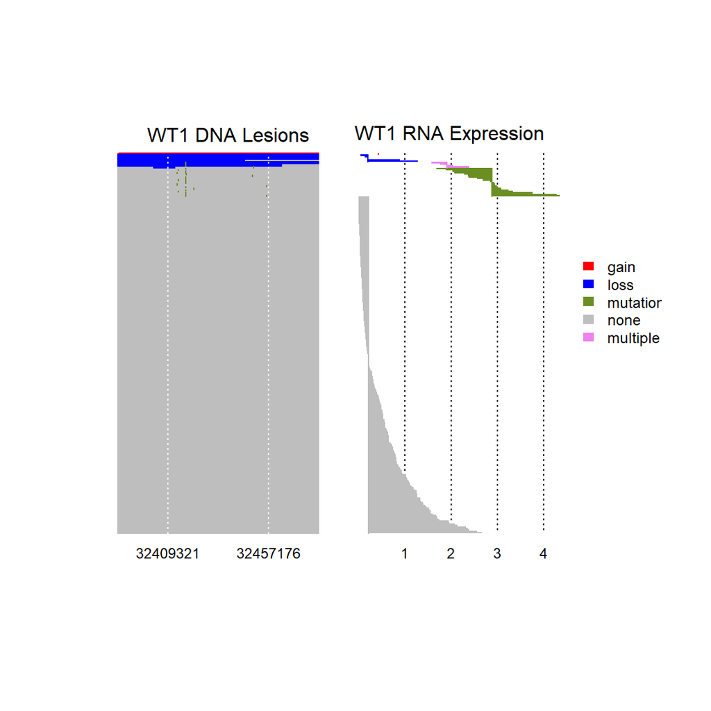

```r
# waterfall plots allow a side-by-side representation of expression and lesion data of the gene of interest.
# First prepare expression and lesion data for waterfall plots:
WT1.waterfall.prep=alex.waterfall.prep(alex.data,
                                        alex.kw.results,
                                        "WT1",
                                        lesion.data)

# alex.waterfall.plot can be used to return the plot
WT1.waterfall.plot=alex.waterfall.plot(WT1.waterfall.prep,
                                        lesion.data)
```

## 24) Return Waterfall Plots for Top Significant Genes

```r
# To prepare Waterfall plots for top significant genes in the KW Results Table, users can use top.alex.waterfall.plots function by specifying a directory to store the plots, and minimum KW.q, for example:

# top.alex.waterfall.plots("folder path/test/waterfall_plots/",
#                          alex.data,
#                          alex.kw.results,
#                          1e-15,
#                          lesion.data)
```

## 25) Run Association Analysis between Lesion and Expression Data on the Pathway Level (JAK/STAT Pathway)

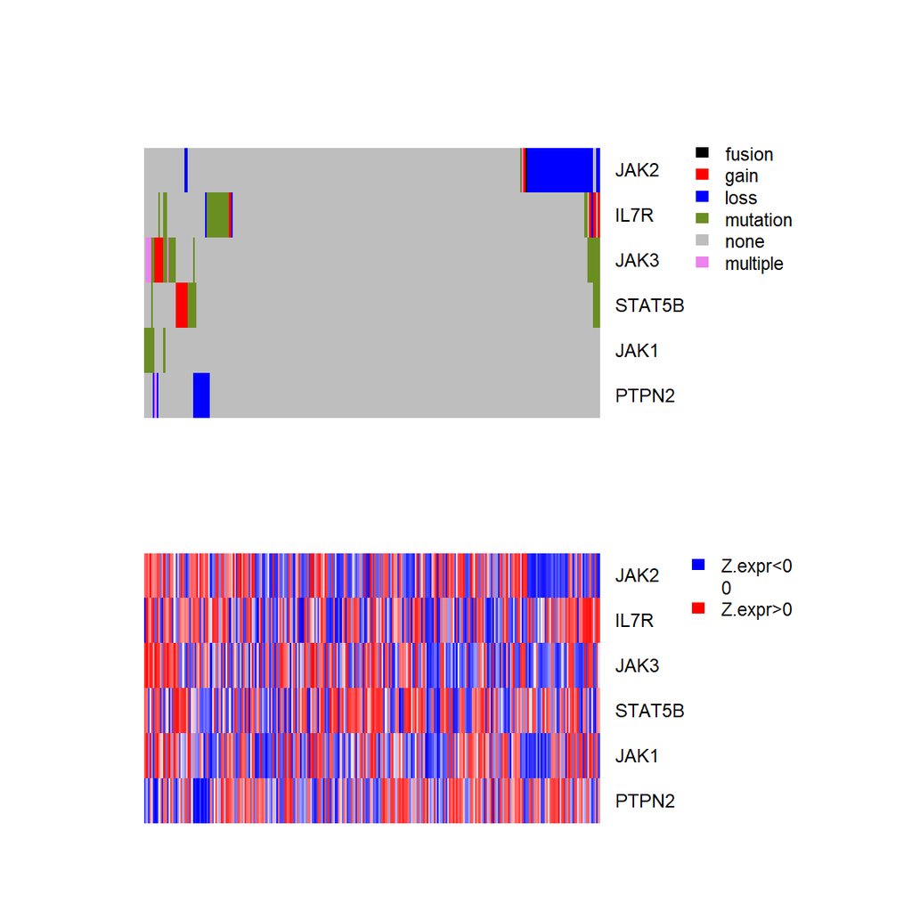

Figure 11. Ordered Lesion and Expression Data based on the Clustering Analysis on the pathway level (JAK/STAT pathway)

```r
# alex.pathway function will run association analysis between lesion and expression data for all genes in a specified pathway (example: JAK/STAT pathway).
# Function will return two panels figure of lesion and expression data of ordered subjects based on the computed lesions distance in all genes assigned to the pathway of interest:
alex.path=alex.pathway(alex.data,
                       lesion.data,
                       pathways,
                       "Jak_Pathway")
```

```r
# To return ordered lesion and expression data of the genes assigned to the pathway of interest (same patients order in the plot):
write.csv(alex.path, "ordered-lesion-expression-data-JAK-pathway-genes.csv")
alex.path[1:10,1:5]
```

```
#>               PARSET   PATZWA   PATITB   PATYJK
#> JAK2 _lsn       none     none     none     none
#> JAK3 _lsn       none multiple multiple multiple
#> JAK1 _lsn   mutation mutation mutation mutation
#> IL7R _lsn       none     none     none     none
#> STAT5B _lsn     none     none     none     none
#> PTPN2 _lsn      none     none     none     none
#> JAK2 _expr     2.772    2.949    2.698    4.288
#> JAK3 _expr     4.566    5.828    4.186     4.96
#> JAK1 _expr     5.106    5.817     4.57    6.296
#> IL7R _expr     1.241    7.267    4.613    4.368
#>               PASHDV
#> JAK2 _lsn       none
#> JAK3 _lsn   mutation
#> JAK1 _lsn   mutation
#> IL7R _lsn       none
#> STAT5B _lsn mutation
#> PTPN2 _lsn      none
#> JAK2 _expr     2.715
#> JAK3 _expr     4.722
#> JAK1 _expr     4.633
#> IL7R _expr     5.775
```

## 26) Lesion Binary Matrix for Association Analysis with Clinical Outcomes

```r
# This type of lesion matrices with each gene affected by a certain type of lesion in a separate row is very helpful to run multiple levels of association analysis that include association between lesions and treatment outcomes.

# Users should first Prepare gene and lesion data and determine lesions that overlap each gene (locus):
gene.lsn=prep.gene.lsn.data(lesion.data,
                            hg19.gene.annotation)
gene.lsn.overlap= find.gene.lsn.overlaps(gene.lsn)

# use prep.binary.lsn.mtx function to prepare the lesion binary matrix:
lsn.binary.mtx.atleast5=prep.binary.lsn.mtx(gene.lsn.overlap,
                                            min.ngrp=5)
# Each row is a lesion type that affect a certain gene for example NOTCH1_mutation (entry will be labelled as 1 if the patient is affected by by this type of lesion and 0 otherwise).
# min.ngrp can be used to specify the minimum number of patients with a lesion to be included in the final lesion matrix.

head(lsn.binary.mtx.atleast5[,1:5])
```

```
#>                          PATXKW PASHNK PARMUC PATKWU
#> ENSG00000005339_mutation      0      1      1      1
#> ENSG00000005700_loss          0      0      0      0
#> ENSG00000006283_gain          0      0      0      0
#> ENSG00000007047_gain          0      0      0      0
#> ENSG00000010438_loss          0      0      0      0
#> ENSG00000010810_loss          0      0      0      0
#>                          PARXMV
#> ENSG00000005339_mutation      1
#> ENSG00000005700_loss          0
#> ENSG00000006283_gain          0
#> ENSG00000007047_gain          0
#> ENSG00000010438_loss          0
#> ENSG00000010810_loss          0
```

## 27) Run Association Analysis for Lesions with Clinical Outcomes

```r
# Prepare Event-free Survival (EFS) and Overall Survival (OS) as survival objects:
clin.data$EFS <- Surv(clin.data$efs.time, clin.data$efs.censor)
clin.data$OS <- Surv(clin.data$os.time, clin.data$os.censor)

# List all clinical variables of interest to be included in the association analysis:
clinvars=c("MRD.binary", "EFS", "OS")

# Run association analysis between lesions and clinical variables:
assc.outcomes=grin.assoc.lsn.outcome(lsn.binary.mtx.atleast5,
                                     clin.data,
                                     hg19.gene.annotation,
                                     clinvars)

# Write the analysis results:
write.csv(assc.outcomes, "associate.lsn.outcomes.csv")

# Run models adjusted for one or a group of covariates:
assc.outcomes.adj=grin.assoc.lsn.outcome(lsn.binary.mtx.atleast5,
                                          clin.data,
                                          hg19.gene.annotation,
                                          clinvars,
                                          covariate="Sex")

write.csv(assc.outcomes.adj, "associate.lsn.outcomes.adj.csv")
```

## 28) Now, let’s Take a Look on the Results Table of the Association between Lesions and Treatment Outcomes:

```r
# order the genes by the ones with most significant KW q-value:
sorted.outcomes <- assc.outcomes[order(as.numeric(as.character(assc.outcomes$`MRD.binary.p-value`))),]
```

First section of the results table will include gene annotation in addition to the odds ratio, lower95, upper95 confidence intervals in addition to p and FDR adjusted q-values for the logistic regression models testing for the association between lesions and binary outcome variables such as Minimal Residual Disease (MRD). COX proportional hazard models will be used in case of survival objects such as Event-free survival (EFS) and Overall Survival (OS) with hazard ratios reported instead of odds ratio:

```r
head(sorted.outcomes[1:7,c(6,11,14,15)])
```

```
#>                          gene.name
#> ENSG00000147889_loss        CDKN2A
#> ENSG00000184937_mutation       WT1
#> ENSG00000099810_loss          MTAP
#> ENSG00000198642_loss         KLHL9
#> ENSG00000171843_loss         MLLT3
#> ENSG00000188352_loss         FOCAD
#>                          MRD.binary.odds.ratio
#> ENSG00000147889_loss                     0.213
#> ENSG00000184937_mutation                 6.889
#> ENSG00000099810_loss                     0.311
#> ENSG00000198642_loss                     0.321
#> ENSG00000171843_loss                     0.225
#> ENSG00000188352_loss                     0.302
#>                          MRD.binary.p-value
#> ENSG00000147889_loss               5.89e-07
#> ENSG00000184937_mutation           2.70e-05
#> ENSG00000099810_loss               7.07e-05
#> ENSG00000198642_loss               6.11e-04
#> ENSG00000171843_loss               1.06e-03
#> ENSG00000188352_loss               1.33e-03
#>                          MRD.binary.q-value
#> ENSG00000147889_loss                0.00012
#> ENSG00000184937_mutation            0.00276
#> ENSG00000099810_loss                0.00482
#> ENSG00000198642_loss                0.02498
#> ENSG00000171843_loss                0.02498
#> ENSG00000188352_loss                0.02498
```

Results table will also include the number of patients with/without lesion who experienced or did not experience the event:

```r
head(sorted.outcomes[1:7,c(6, 16:19)])
```

```
#>                          gene.name
#> ENSG00000147889_loss        CDKN2A
#> ENSG00000184937_mutation       WT1
#> ENSG00000099810_loss          MTAP
#> ENSG00000198642_loss         KLHL9
#> ENSG00000171843_loss         MLLT3
#> ENSG00000188352_loss         FOCAD
#>                          MRD.binary.event.with.lsn
#> ENSG00000147889_loss                            37
#> ENSG00000184937_mutation                        16
#> ENSG00000099810_loss                            36
#> ENSG00000198642_loss                            14
#> ENSG00000171843_loss                             6
#> ENSG00000188352_loss                            10
#>                          MRD.binary.event.without.lsn
#> ENSG00000147889_loss                               33
#> ENSG00000184937_mutation                           54
#> ENSG00000099810_loss                               34
#> ENSG00000198642_loss                               56
#> ENSG00000171843_loss                               64
#> ENSG00000188352_loss                               60
#>                          MRD.binary.no.event.with.lsn
#> ENSG00000147889_loss                              163
#> ENSG00000184937_mutation                            8
#> ENSG00000099810_loss                              150
#> ENSG00000198642_loss                               85
#> ENSG00000171843_loss                               57
#> ENSG00000188352_loss                               69
#>                          MRD.binary.no.event.without.lsn
#> ENSG00000147889_loss                                  31
#> ENSG00000184937_mutation                             186
#> ENSG00000099810_loss                                  44
#> ENSG00000198642_loss                                 109
#> ENSG00000171843_loss                                 137
#> ENSG00000188352_loss                                 125
```

## 29) Evaluate CNVs (Gain and Deletions) as Lesion Boundaries

```r
# This analysis is lesion type specific and covers the entire genome.It's meant to cover and asses the regions without any annotated genes or regulatory features. The first boundary for each chromosome will start from the first nucleotide base on the chromosome till the start position of the first lesion that affect the chromosome. Similarly, the last boundary will start from the end position of the last lesion that affect the chromosome till the last base on the chromosome.

# First extract data for gains and deletions from the lesion data file:
gain=lesion.data[lesion.data$lsn.type=="gain",]
loss=lesion.data[lesion.data$lsn.type=="loss",]

# Then use grin.lsn.boundaries function to return the lesion boundaries:
lsn.bound.gain=grin.lsn.boundaries(gain, hg19.chrom.size)
lsn.bound.loss=grin.lsn.boundaries(loss, hg19.chrom.size)

# It return a table of ordered boundaries based on the unique start and end positions of different lesions in a specific category on each chromosome.
head(lsn.bound.loss[,1:5])
```

```
#>                  gene chrom loc.start loc.end    diff
#> 1        chr1_1_51585     1         1   51585   51584
#> 2   chr1_51586_593440     1     51586  593440  541854
#> 3  chr1_593441_711152     1    593441  711152  117711
#> 4  chr1_711153_713167     1    711153  713167    2014
#> 5  chr1_713168_751594     1    713168  751594   38426
#> 6 chr1_751595_2247723     1    751595 2247723 1496128
```

## 30) Run GRIN analysis Using Lesion Boundaries Instead of the Gene Annotation File

```r
grin.results.gain.bound=grin.stats(gain,
                                   lsn.bound.gain,
                                   hg19.chrom.size)
write.grin.xlsx(grin.results.gain.bound, "GRIN.results.gain.boundaries.final.xlsx")

grin.results.loss.bound=grin.stats(loss,
                                   lsn.bound.loss,
                                   hg19.chrom.size)
write.grin.xlsx(grin.results.loss.bound, "GRIN.results.loss.boundaries.final.xlsx")
```

## 31) Genome-wide Significance Plot for Loss Lesion Boundaries

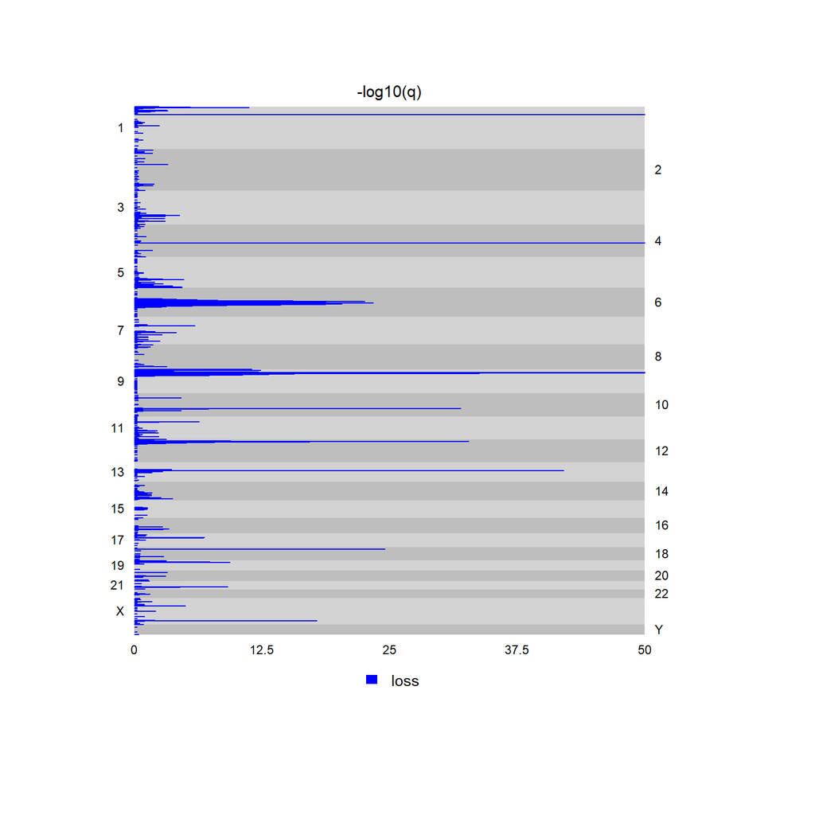

Figure 12. Genome-wide -log10q plot of loss lesion boundaries

```r
# genomewide.log10q.plot function will return a genome-wide plot based on -log(10) q-value testing if each of the evaluated lesion boundaries is significantly affect by a deletions in our example:
genomewide.log10q.plot(grin.results.loss.bound,
                       lsn.grps=c("loss"),
                       lsn.colors=c("loss" = "blue"),
                       max.log10q = 50)
```